# Exploring 2016 Twitter Trolls

Benjamin Ortiz Ulloa

1/26/2019

```r
library(tidyverse)
library(igraph)
```

At last year’s Data Days Texas, Will Lyon spoke about [Neo4j’s findings with regards to the 2016 Russian Twitter Trolls](https://neo4j.com/blog/story-behind-russian-twitter-trolls/). They were able to do this analysis on the data [NBC collected](https://www.kaggle.com/vikasg/russian-troll-tweets). Let’s explore the same data set and see what we can learn.

```r
tweets <- read_csv('russian-troll-tweets/tweets.csv')
```

To start off we’ll only need the users’ identification key and their hashtag information. We’ll also need the text of the tweets for future referece.

```r
tweet_hashtag <- tweets %>%
  filter(hashtags != '[]') %>% #this represents a tweet with no hashtags
  mutate(hashtags = map(hashtags, jsonlite::fromJSON)) %>% #the stored info is a json file
  select(user_key, hashtags, text) %>%
  unnest()

head(tweet_hashtag)
```

```
## # A tibble: 6 x 3
##   user_key     text                                        hashtags
##   <chr>        <chr>                                       <chr>
## 1 ryanmaxwell… #IslamKills Are you trying to say that the… IslamKills
## 2 queenofthewo RT @jww372: I don't have to guess your rel… ChristmasAfter…
## 3 hiimkhloe    One of the ways to remind that #BlackLives… Blacklivesmatt…
## 4 jasper_fly   RT @ElPenguinito: #myfarewellwordswouldbe … MyFarewellWord…
## 5 giselleevns  #My2017BiggestHope to reach this level of … My2017BiggestH…
## 6 pamela_moor… "The war is here! \nThis gentleman made mo… Obama
```

Since we are only working with an edge list, we should create a directed graph in which people point to hashtags. This is useful since we can infer a node type by where it lies on a given edge.

```r
# user -[used hashtag]-> hashtag
tweet_hashtag_edges <- tweet_hashtag %>%
  select(-text) %>%
  count(user_key, hashtags, sort = T) %>% #aggregatign user-hashtag occurances
  rename(weight = n) %>%
  mutate(type = 'used_hashtag',
         user_key = paste0('@', user_key), #prevent duplicate node names
         hashtags = paste0('#', hashtags) #prevent duplicate node names
         )

head(tweet_hashtag_edges)
```

```
## # A tibble: 6 x 4
##   user_key         hashtags  weight type
##   <chr>            <chr>      <int> <chr>
## 1 @newspeakdaily   #Politics    735 used_hashtag
## 2 @ameliebaldwin   #maga        605 used_hashtag
## 3 @kansasdailynews #news        573 used_hashtag
## 4 @onlinecleveland #Politics    501 used_hashtag
## 5 @washingtonline  #Politics    393 used_hashtag
## 6 @todaybostonma   #Politics    382 used_hashtag
```

We now have an edge list with enough information to get started. We should give the nodes plotting attributes so we can plot the graph later.

```r
tweet_hashtag_nodes <- bind_rows(
  tibble(
    label = tweet_hashtag_edges$user_key %>% unique(),
    type = 'user',
    color = 'purple',
    size = 3
  ),
  tibble(
    label = tweet_hashtag_edges$hashtags %>% unique(),
    type = 'hashtag',
    color = 'lightgrey',
    size = 3
  )
)
```

```r
tweet_hashtag_g <- tweet_hashtag_edges %>%
  graph_from_data_frame(vertices = tweet_hashtag_nodes)

tweet_hashtag_g
```

```
## IGRAPH 9e8e65b DNWB 13336 36366 --
## + attr: name (v/c), type (v/c), color (v/c), size (v/n), weight
## | (e/n), type (e/c)
## + edges from 9e8e65b (vertex names):
##  [1] @newspeakdaily  ->#Politics
##  [2] @ameliebaldwin  ->#maga
##  [3] @kansasdailynews->#news
##  [4] @onlinecleveland->#Politics
##  [5] @washingtonline ->#Politics
##  [6] @todaybostonma  ->#Politics
##  [7] @hyddrox        ->#maga
## + ... omitted several edges
```

This is a big graph. This will look like a gian hair ball if we plot it. Also, we are only interested in frequent person-hashtag connections. Let’s take a look at the weight distribution.

```r
summary(E(tweet_hashtag_g)$weight)
```

```
##    Min. 1st Qu.  Median    Mean 3rd Qu.    Max.
##   1.000   1.000   1.000   3.331   2.000 735.000
```

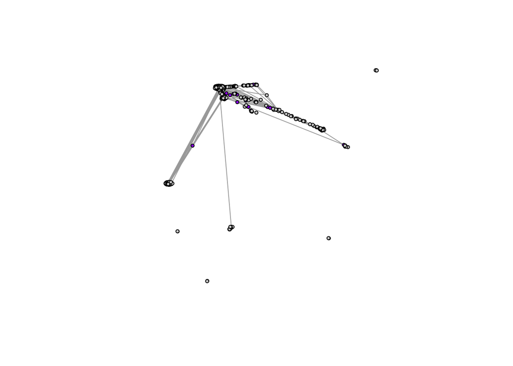

```r
# let's filter the graph down
tweet_hashtag_g_filtered <- tweet_hashtag_g %>%
  {. - E(.)[weight <= 5]} %>%
  {. - V(.)[degree(.) == 0]}

plot(tweet_hashtag_g_filtered,
     vertex.label = '',
     edge.arrow.mode = '-')
```

From the looks of it, the is not a complete graph. That is, not every node can be connected with every other node. This shows that their are different groups, or component. Let’s take a look at the differentcomponents

```r
tweet_hashtag_g_filtered_components <- components(tweet_hashtag_g_filtered)

names(tweet_hashtag_g_filtered_components)
```

```
## [1] "membership" "csize"      "no"
```

```r
tweet_hashtag_g_filtered_components %>%
  groups() %>%
  map(head, n = 10)
```

```
## $`1`
##  [1] "@newspeakdaily"   "@ameliebaldwin"   "@kansasdailynews"
##  [4] "@onlinecleveland" "@washingtonline"  "@todaybostonma"
##  [7] "@hyddrox"         "@giselleevns"     "@batonrougevoice"
## [10] "@specialaffair"
##
## $`2`
## [1] "@darknally" "#Foke"
##
## $`3`
## [1] "@itstimetosecede" "#Texit"
##
## $`4`
## [1] "@eliasbrick"           "@javonhidp"            "#FlintHealthEmergency"
## [4] "#FlintWaterCrisis"
##
## $`5`
## [1] "@jeblary2016"  "#FakeDNCFacts"
```

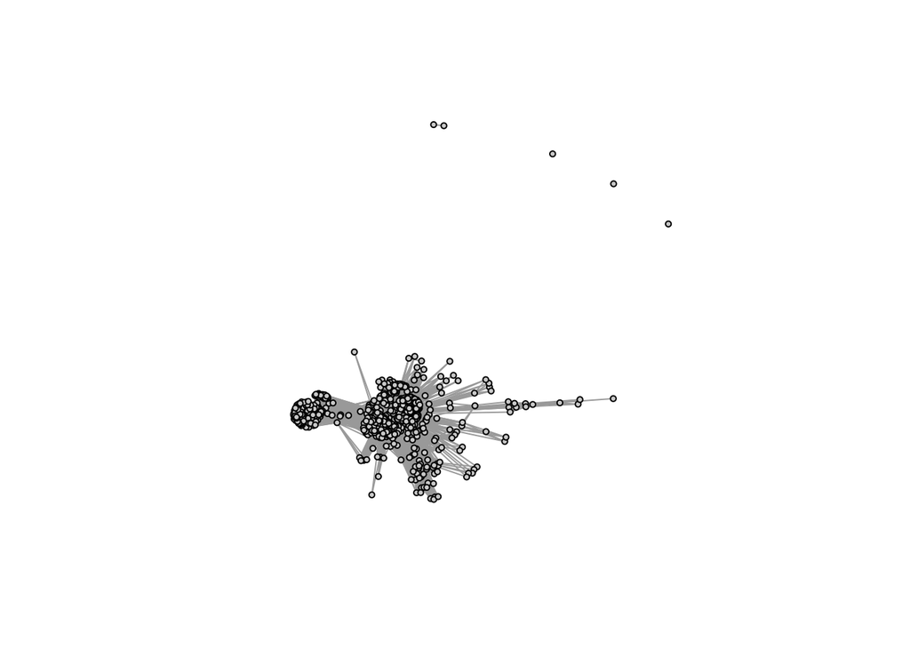

```r
tweet_hashtag_g_filtered %>%
  {
    V(.)$type <- V(.)$type == 'user'; #boolean type is necessary for bipartite projection
    V(.)$degree <- degree(.);
    V(.)$weighted_degree <- strength(.);
    .
  } %>%
  igraph::bipartite_projection() %>%
  {
    . <- map(., function(x){
      V(x)$component <- components(x)$membership;
      return(x)
    })
    hashtag_g <<- .$proj1; #projection 1 is type FALSE
    user_g <<- .$proj2; #projection 2 is type TRUE
  }
set.seed(4321)
plot(hashtag_g, vertex.size = 3, vertex.label = '')
```

There is a large component within the tweets. We can distiguish them by using a community detection algorithm and marking the nodes according to their community. The **walktrap algorthm** uses a series of random walks to determine who are in the same community.

```r
hashtag_communities <- walktrap.community(hashtag_g)

hashtag_communities %>%
  groups %>%
  map(function(grp){str_replace(grp, '^[^_]+_', '') %>% head(10)} )
```

```
## $`1`
##  [1] "#nowplaying"                "#Listen2"
##  [3] "#God"                       "#SoundCloud"
##  [5] "#np"                        "#Tashify"
##  [7] "#artyoucanhear"             "#SearchesGoogleIsAshamedOf"
##  [9] "#RAPStationRadio"           "#hiphop"
##
## $`2`
## [1] "#INDIGENOUS" "#TAIRP"      "#BlackUnity" "#MSNBC"      "#MorningJoe"
##
## $`3`
##  [1] "#MerkelMussBleiben" "#Merkel"            "#G20"
##  [4] "#Morgen"            "#MerkelsErfolge"    "#Hamburg"
##  [7] "#CDU"               "#Freitag"           "#Brexit"
## [10] "#afd"
##
## $`4`
##  [1] "#Politics"            "#maga"                "#news"
##  [4] "#Trump"               "#NeverHillary"        "#TopVideo"
##  [7] "#RealLifeMagicSpells" "#tcot"                "#world"
## [10] "#Trump2016"
##
## $`5`
## [1] "#Syria"  "#Iraq"   "#Mosul"  "#Aleppo" "#SAA"
##
## $`6`
##  [1] "#MakeMeHateYouInOnePhrase" "#SometimesItsOkTo"
##  [3] "#IdRunForPresidentIf"      "#RuinADinnerInOnePhrase"
##  [5] "#ThingsNotTaughtAtSchool"  "#2017SurvivalTips"
##  [7] "#ImTooOldFor"              "#ChristmasAftermath"
##  [9] "#My2017Resolution"         "#IHaveARightToKnow"
##
## $`7`
## [1] "#PodernFamily"  "#HiddenFigures" "#SciFiSunday"   "#podcast"
## [5] "#ObamaFarewell"
##
## $`8`
## [1] "#FlintHealthEmergency" "#FlintWaterCrisis"
##
## $`9`
## [1] "#Foke"
##
## $`10`
## [1] "#JugendmitMerkel"
##
## $`11`
## [1] "#Texit"
##
## $`12`
## [1] "#FakeDNCFacts"
```

While some of these tweets look somewhat normal, they take on a completely different tone once we understand that they come from a troll.

```r
tweet_hashtag %>%
  filter(hashtags == 'Texit')
```

```
## # A tibble: 11 x 3
##    user_key      text                                             hashtags
##    <chr>         <chr>                                            <chr>
##  1 itstimetosec… How come we ain't independent yet? Get rid of f… Texit
##  2 itstimetosec… No matter how far we may wander, TEXAS lingers … Texit
##  3 itstimetosec… @TXBaCoNMaSTeR Hey!  Would you like to particip… Texit
##  4 itstimetosec… You either support #Texit or you're wrong. Peri… Texit
##  5 itstimetosec… We estimated our opportunities and drafted a ma… Texit
##  6 itstimetosec… The #Texit rallies start in two hours. Join us … Texit
##  7 itstimetosec… Secession is not just an idea, it's our one and… Texit
##  8 itstimetosec… DC hypocrites! Hands off our constitutional rig… Texit
##  9 itstimetosec… This is our choice no matter who wins this elec… Texit
## 10 itstimetosec… We can't make the whole country vote Trump, but… Texit
## 11 itstimetosec… Hey y'all how 'bout our very own Texas election… Texit
```

```r
  # filter(hashtags == 'BTP')
  # filter(hashtags == 'PodernFamily')
```

We can mark the nodes according to the community algorithm. The order of membership information returned from the algorithm corresponds to the order of the vertices of the graph used.

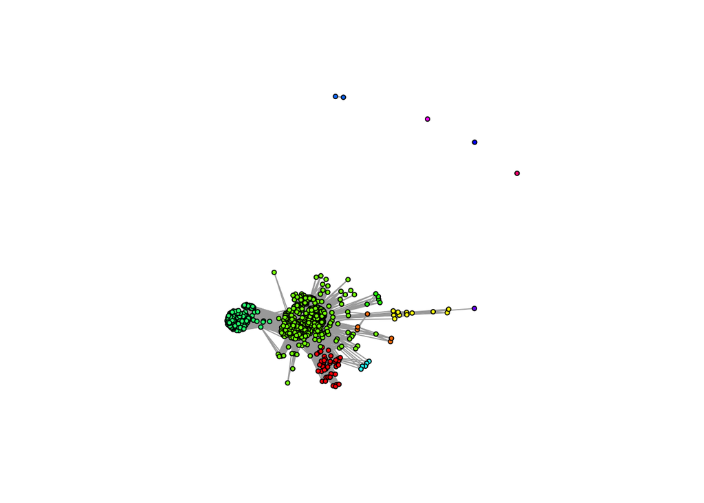

```r
V(hashtag_g)$membership <- hashtag_communities$membership

vertex_clr_palette <- rainbow(hashtag_communities %>% groups %>% length()) #simple color palette

set.seed(4321)
hashtag_g %>%
  plot(
    vertex.color = map_chr(V(.)$membership, function(x){vertex_clr_palette[x]}),
    vertex.label = ''
  )
```

We can create super nodes that represent the community’s discovered. The edges between the super nodes would represent users who tweeted hashtags from both.

```r
hashtag_community_summary <- hashtag_g %>%
  {
    E(.)$tailCommunity <- tail_of(., E(.))$membership; #store node information in edges
    E(.)$headCommunity <- head_of(., E(.))$membership; #to refrence later
    .
  } %>%
  as_data_frame('both') %>%
  {
    el <- .$edges %>%
      filter(tailCommunity != headCommunity) %>%
      #1 - 6 is same as 6 - 1
      mutate(
        tail = map2_dbl(tailCommunity, headCommunity, min) %>% round %>% as.character(),
        head = map2_dbl(tailCommunity, headCommunity, max) %>% round %>% as.character()
      ) %>%
      group_by(tail, head) %>%
      nest() %>%
      mutate(data = map(data, function(x){
        top_hashes <- x %>%
          arrange(desc(weight)) %>%
          head(3) %>%
          {paste(.$from, .$to, sep = ' | ', collapse = '\n')} %>%
          str_replace_all('hashtag_', '')

        tibble(
          top_hashes,
          sum_weight = sum(x$weight),
          ave_weight = mean(x$weight),
          count = nrow(x)
        )
      })) %>%
      unnest()

    nl <- .$vertices %>%
      mutate(membership = as.character(membership)) %>%
      group_by(membership) %>%
      nest() %>%
      mutate(top_hashes = map_chr(data, function(x){
        x %>%
          head %>%
          .$name %>%
          paste(collapse = '\n') %>%
          str_replace_all('hashtag_', '')
      }))

    set.seed(4321)
    graph_from_data_frame(el, F, nl) %>%
      {
        l <- layout_nicely(.) #store layout information in vertices
        V(.)$x <- l[,1]
        V(.)$y <- l[,2]
        .
      }
  }
```

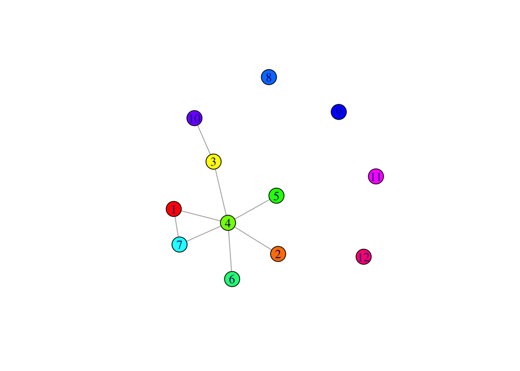

```r
hashtag_community_summary %>%
  plot(vertex.color = map_chr(V(.)$name, function(x){vertex_clr_palette[as.numeric(x)]}))
```

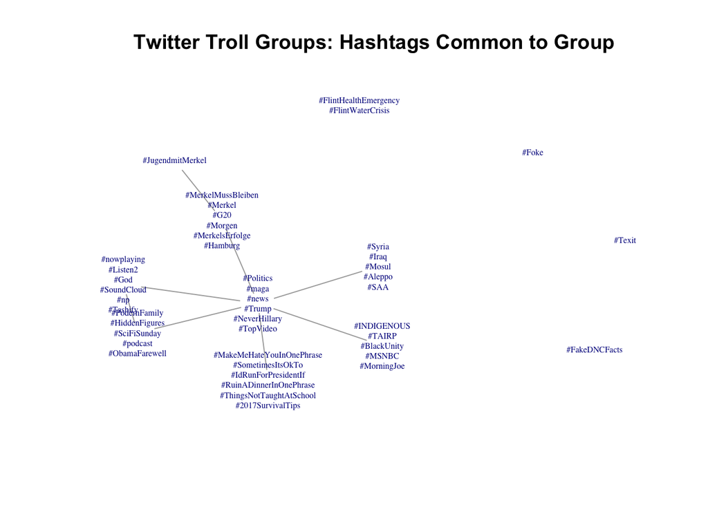

```r
hashtag_community_summary %>%
  plot(
    vertex.label = V(.)$top_hashes,
    vertex.label.cex = .5,
    vertex.shape = 'none',
    main = 'Twitter Troll Groups: Hashtags Common to Group',
    asp = 0)
```

[figure not shown]

```r
hashtag_community_summary %>%
  {. - V(.)[degree(.) == 0]} %>%
  plot(
    edge.label = E(.)$top_hashes,
    edge.label.cex = .5,
    vertex.size = 5,
    main = "Twitter Troll Groups: Hashtags Connecting two Groups",
    asp = 0
  )
```

## Text Analysis

Please take a look at the corresponding slides before continuing

The theme of tagging a node is important because we don’t always have direct connections to determine if two nodes are related. Community detection relies on the network’s structure. Luckily, we have text stored in the nodes so another option that we have for identifying nodes is topic modelling.

```r
library(tidytext)
library(stm)
```

Topic modelling typically requires a form of document-term matrix. This is simply a matrix that counts the occurance of a particular word in a particular document. This requires us to figure out to extract word frequencies. This would normally involve tokenization and the removal of stop word’s, but another beautiful thing about working with twitter data is that the hashtags themselves are tokenized words.

```r
#https://juliasilge.com/blog/evaluating-stm/
tidy_hash <- tweet_hashtag %>%
  select(-text) %>%
  count(user_key, hashtags, sort = T)

head(tidy_hash)
```

```
## # A tibble: 6 x 3
##   user_key        hashtags     n
##   <chr>           <chr>    <int>
## 1 newspeakdaily   Politics   735
## 2 ameliebaldwin   maga       605
## 3 kansasdailynews news       573
## 4 onlinecleveland Politics   501
## 5 washingtonline  Politics   393
## 6 todaybostonma   Politics   382
```

Once we have the term frequencies, we can store the counts in the intersection of the words and documents.

```r
tweets_sparse_hash <- tidy_hash %>%
  cast_sparse(user_key, hashtags, n)
tweets_sparse_hash[1:5, 1:5]
```

```
## 5 x 5 sparse Matrix of class "dgCMatrix"
##                 Politics maga news MakeMeHateYouInOnePhrase Trump
## newspeakdaily        735    .    .                        .     .
## ameliebaldwin          2  605    6                        .   322
## kansasdailynews      326    .  573                        .     .
## onlinecleveland      501    .    .                        .     .
## washingtonline       393    .    8                        .     .
```

We can then use the dtm to run a topic model. There are many topic modelling algorithms - a common one is the latent Dirichlet allocation - however, here we use a structural topic model. These algorithms genreally take some time

```r
# topic_model_hash <- stm(tweets_sparse_hash, K = 6,
#                         verbose = FALSE, init.type = "Spectral")


topic_model_hash <- read_rds('created_data/twitter_troll_tweets_user_hash.rds')
topic_model_hash
```

```
## A topic model with 6 topics, 401 documents and a 12935 word dictionary.
```

One of the return values of the STM model is a beta value which tells us the probability a word belongs to a topic.

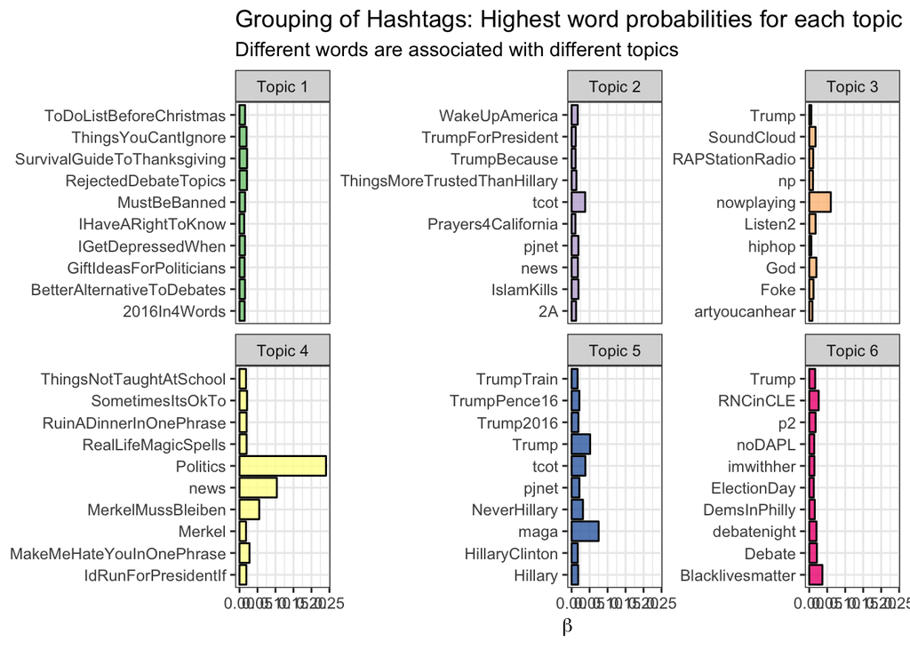

```r
td_beta_hash <- tidy(topic_model_hash)

td_beta_hash %>%
  filter(term != 'rt') %>%
  group_by(topic) %>%
  top_n(10, beta) %>%
  ungroup() %>%
  mutate(topic = paste0("Topic ", topic)) %>%
  ggplot(aes(term, beta, fill = as.factor(topic))) +
  geom_col(alpha = 0.8, show.legend = FALSE, color = 'black') +
  facet_wrap(~ topic, scales = "free_y") +
  coord_flip() +
  labs(x = NULL, y = expression(beta),
       title = "Grouping of Hashtags: Highest word probabilities for each topic",
       subtitle = "Different words are associated with different topics") +
  scale_fill_brewer(type = 'qual') +
  theme_bw()
```

We also have a gamma, which tells us the probability that a given document (or, in our case, troll) belongs to a particular topic.

```r
td_gamma_hash <- tidy(topic_model_hash, matrix = "gamma",
                      document_names = rownames(tweets_sparse_hash)) %>%
  arrange(document)

categorize_user <- td_gamma_hash %>%
  group_by(document) %>%
  top_n(1, gamma) %>%
  mutate(color = map_chr(topic, function(x){scales::brewer_pal('qual')(6)[x]})) %>%
  rename(name = document)

categorize_user
```

```
## # A tibble: 401 x 4
## # Groups:   name [401]
##    name          topic gamma color
##    <chr>         <int> <dbl> <chr>
##  1 _billy_moyer_     2 0.996 #BEAED4
##  2 _nickluna_        2 0.785 #BEAED4
##  3 _sashalapin       5 0.926 #386CB0
##  4 4mysquad          6 0.957 #F0027F
##  5 6druz             2 0.397 #BEAED4
##  6 aantiracist       6 0.880 #F0027F
##  7 abigailssilk      1 0.638 #7FC97F
##  8 acejinev          6 0.921 #F0027F
##  9 adamchapmanjr     6 0.794 #F0027F
## 10 adrgreerr         6 0.677 #F0027F
## # ... with 391 more rows
```

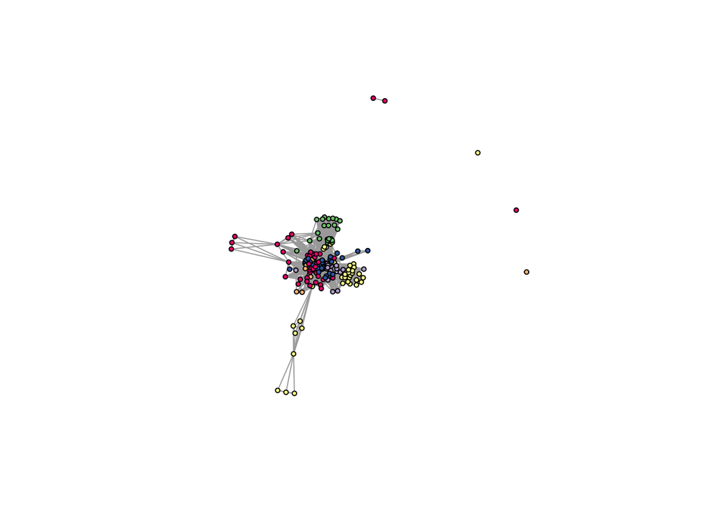

```r
colored_user_g <- user_g %>%
  as_data_frame('both') %>%
  {
    el <- .$edges %>%
      mutate(
        from = str_remove(from, '^@'),
        to = str_remove(to, '^@')
      )

    nl <- .$vertices %>%
      remove_rownames() %>%
      select(-color) %>%
      mutate(
        name = str_remove(name, '^@')
      ) %>%
      left_join(categorize_user, by = "name")

    graph_from_data_frame(el, F, nl)
  }

plot(colored_user_g, vertex.label = '')
```